# 고령화연구패널조사(KLoSA) 데이터분석

### 3) ADL 현황 ((2006년 66세 ~ 85세)

```r
klosabyage %>% filter(!is.na(adl)&!is.na(year)) %>%
    select(year,age,tfr,adl) %>%
    mutate(adl=ifelse(adl > 0 , 1, 0)) %>%
    #filter(adl!=0) %>%
    count(year,tfr,adl) %>%
    group_by(year,tfr) %>%
    mutate(total=sum(n)) %>%
    filter(adl==1) %>%
    mutate(pct=round(n/total*100,1))->adl_line
```

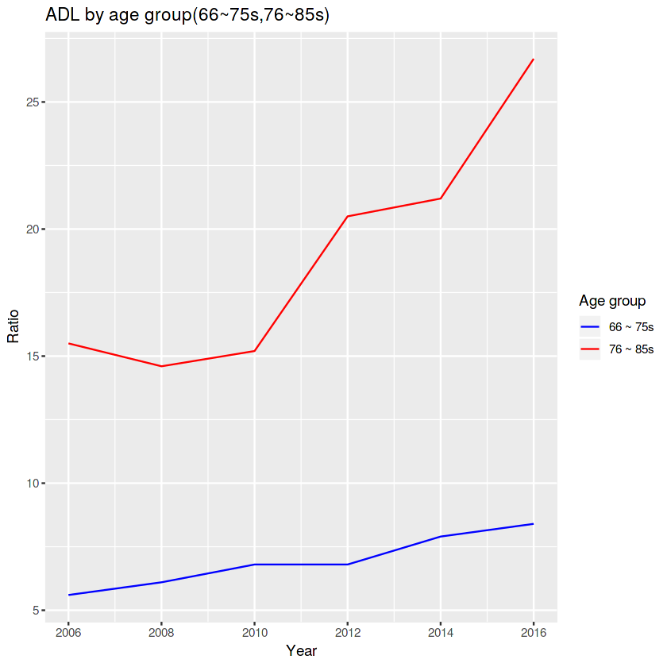

```r
ggplot(adl_line[adl_line$tfr %in% c("66to75","76to85"),],aes(year,pct,color=factor(tfr)))+
    geom_line()+
    labs(y="Ratio",x="Year",title="ADL by age group(66~75s,76~85s)")+
    scale_color_manual( values=c("Blue","Red"),
                        name = ("Age group"),
                        labels = c("66 ~ 75s","76 ~ 85s"))
```

### 4) 일상생활 수행 장애율(70s, 80S~)

```r
klosa %>% select(year,ageg,change_clothes,bath,meal,out_of_room,toilet,urin)  %>%
    filter(ageg=="70s"| ageg=="80s~") %>%
    mutate(change_clothes=ifelse(change_clothes==1,0,1)) %>%
    mutate(bath=ifelse(bath==1,0,1)) %>%
    mutate(meal=ifelse(meal==1,0,1)) %>%
    mutate(out_of_room=ifelse(out_of_room==1,0,1)) %>%
    mutate(toilet=ifelse(toilet==1,0,1)) %>%
    mutate(urin=ifelse(urin==1,0,1)) ->adl_count

adl_count %>% group_by(year,ageg,change_clothes)  %>%
    summarize(count=n()) %>%
    mutate(class="change_clothes") %>%
    mutate(total=sum(count)) %>%
    mutate(pct=round(count/total*100,1)) %>%
    filter(change_clothes!=0) ->m1

adl_count %>% group_by(year,ageg,bath)  %>%
    summarize(count=n()) %>%
    mutate(class="bath") %>%
    mutate(total=sum(count)) %>%
    mutate(pct=round(count/total*100,1)) %>%
    filter(bath!=0)->m2

adl_count %>% group_by(year,ageg,meal)  %>%
    summarize(count=n()) %>%
    mutate(class="meal") %>%
    mutate(total=sum(count)) %>%
    mutate(pct=round(count/total*100,1)) %>%
    filter(meal!=0)->m3

adl_count %>% group_by(year,ageg,out_of_room)  %>%
    summarize(count=n()) %>%
    mutate(class="out_of_room") %>%
    mutate(total=sum(count)) %>%
    mutate(pct=round(count/total*100,1)) %>%
    filter(out_of_room!=0)->m4

adl_count %>% group_by(year,ageg,toilet)  %>%
    summarize(count=n()) %>%
    mutate(class="toilet") %>%
    mutate(total=sum(count)) %>%
    mutate(pct=round(count/total*100,1)) %>%
    filter(toilet!=0)->m5

adl_count %>% group_by(year,ageg,urin)  %>%
    summarize(count=n()) %>%
    mutate(class="urin") %>%
    mutate(total=sum(count)) %>%
    mutate(pct=round(count/total*100,1)) %>%
    filter(urin!=0)->m6

rbind(m1,m2,m3,m4,m5,m6) -> adl_bind
adl_bind %>%  select(year,ageg,class,count,total,pct)->adl_bind
```

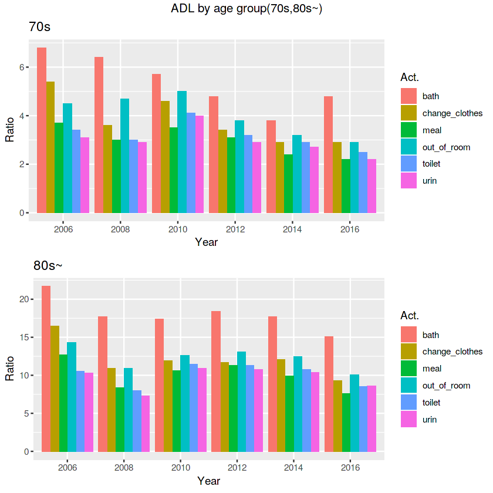

```r
ggplot(adl_bind[adl_bind$ageg=="70s",],aes(factor(year),pct,fill=factor(class)))+
    geom_col(position="dodge")+
    labs(y="Ratio",x="Year",title="70s") +
    theme_grey()+
    scale_fill_discrete(name = "Act.")->adl1

ggplot(adl_bind[adl_bind$ageg=="80s~",],aes(factor(year),pct,fill=factor(class)))+
    geom_col(position="dodge")+
    labs(y="Ratio",x="Year",title="80s~") +
    theme_grey()+
    scale_fill_discrete(name = "Act.")->adl2

grid.arrange(adl1, adl2, top="ADL by age group(70s,80s~)", nrow = 2)
```

### 6.2 IADL(Instrumental Activities of Daily Living) - 도구적 일상 활동 수행 능력

- prepare_meal: 식사준비
- gloom: 몸단장 하기
- clean: 일상적인 집안일(청소 등)
- laun: 빨래하기(세탁, 빨래 널고 말리기 등)
- out: 가까운 거리 외출(교통수단 미이용)
- bus: 교통수단 이용하여 외출하기
- buying: 상점에서 물건사기
- m_manage: 금전관리(용돈/통장/재산관리 등)
- phone_call: 전화걸고 받기
- medicine: 약 챙겨 먹기

### 1) IADL 장애율

```r
klosa %>% select(year,ageg, iadl) %>%
    mutate(adl=ifelse(iadl > 0, 1, 0)) %>%
    count(year,ageg,iadl) %>%
    group_by(year,ageg) %>%
    mutate(total=sum(n)) %>%
    filter(iadl==1) %>%
    mutate(pct=round(n/total*100,1))-> iadl_rate
```

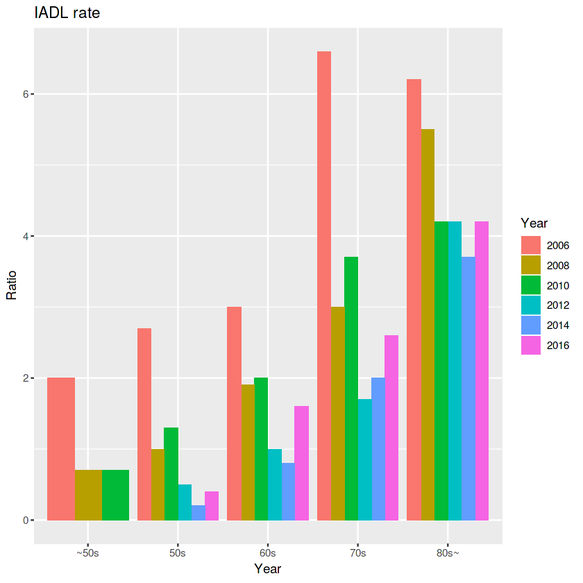

```r
iadl_rate %>% ggplot(aes(ageg,pct,fill=factor(year)))+
    geom_col(position="dodge")+
    labs(y="Ratio",x="Year",title="IADL rate") +
    theme_grey()+
    scale_fill_discrete(name = "Year")
```

### 2) 성별 IADL 장애율

```r
klosa %>% select(year,gender, iadl) %>%
    mutate(adl=ifelse(iadl > 0, 1, 0)) %>%
    count(year,gender,iadl) %>%
    group_by(year,gender) %>%
    mutate(total=sum(n)) %>%
    filter(iadl==1) %>%
    mutate(pct=round(n/total*100,1))-> iadl_genrate
```

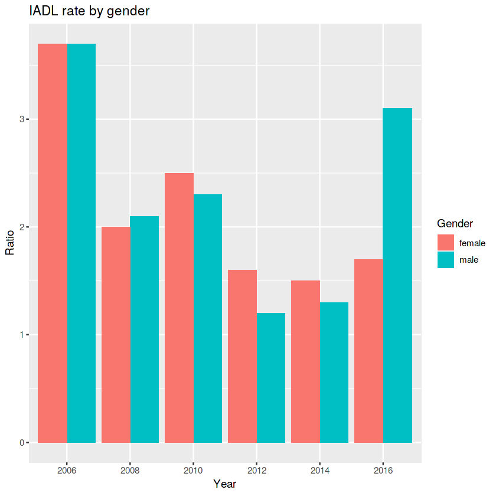

```r
iadl_genrate %>% ggplot(aes(factor(year),pct,fill=factor(gender)))+
    geom_col(position="dodge")+
    labs(y="Ratio",x="Year",title="IADL rate by gender") +
    theme_grey()+
    scale_fill_discrete(name = "Gender")
```

### 3) IADL 현황 ((2006년 66세 ~ 85세)

```r
klosabyage %>% filter(!is.na(iadl)&!is.na(year)) %>%
    select(year,age,tfr,iadl) %>%
    mutate(iadl=ifelse(iadl > 0, 1, 0)) %>%
    #filter(adl!=0) %>%
    count(year,tfr,iadl) %>%
    group_by(year,tfr) %>%
    mutate(total=sum(n)) %>%
    filter(iadl==1) %>%
    mutate(pct=round(n/total*100,1))->iadl_line
```

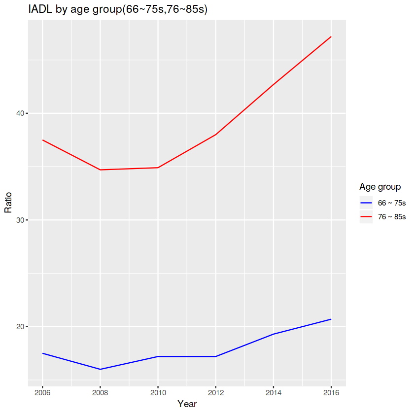

```r
ggplot(iadl_line[iadl_line$tfr %in% c("66to75","76to85"),],aes(year,pct,color=factor(tfr)))+
    geom_line()+
    labs(y="Ratio",x="Year",title="IADL by age group(66~75s,76~85s)")+
    scale_color_manual( values=c("Blue","Red"),
                        name = ("Age group"),
                        labels = c("66 ~ 75s","76 ~ 85s"))
```

### 4) 도구적 일상 활동 장애율(70s, 80S~)

```r
klosa %>% select(year,ageg,prepare_meal,gloom,clean,laun,out,bus,buying,m_manage,phone_call,medicine) %>%
          mutate(prepare_meal=ifelse(prepare_meal==1,0,1)) %>%
          mutate(gloom=ifelse(gloom==1,0,1)) %>%
          mutate(clean=ifelse(clean==1,0,1)) %>%
          mutate(laun=ifelse(laun==1,0,1)) %>%
          mutate(out=ifelse(out==1,0,1)) %>%
          mutate(bus=ifelse(bus==1,0,1)) %>%
          mutate(buying=ifelse(buying==1,0,1)) %>%
          mutate(m_manage=ifelse(m_manage==1,0,1)) %>%
          mutate(phone_call=ifelse(phone_call==1,0,1)) %>%
          mutate(medicine=ifelse(medicine==1,0,1)) ->iadl_count

iadl_count %>% group_by(year,ageg,prepare_meal)  %>%
    summarize(count=n()) %>%
    mutate(class="prepare_meal") %>%
    mutate(total=sum(count)) %>%
    mutate(pct=round(count/total*100,1)) %>%
    filter(prepare_meal!=0) ->n1

iadl_count %>% group_by(year,ageg,gloom)  %>%
    summarize(count=n()) %>%
    mutate(class="gloom") %>%
    mutate(total=sum(count)) %>%
    mutate(pct=round(count/total*100,1)) %>%
    filter(gloom!=0) ->n2

iadl_count %>% group_by(year,ageg,clean)  %>%
    summarize(count=n()) %>%
    mutate(class="clean") %>%
    mutate(total=sum(count)) %>%
    mutate(pct=round(count/total*100,1)) %>%
    filter(clean!=0) ->n3

iadl_count %>% group_by(year,ageg,laun)  %>%
    summarize(count=n()) %>%
    mutate(class="laun") %>%
    mutate(total=sum(count)) %>%
    mutate(pct=round(count/total*100,1)) %>%
    filter(laun!=0) ->n4

iadl_count %>% group_by(year,ageg,out)  %>%
    summarize(count=n()) %>%
    mutate(class="out") %>%
    mutate(total=sum(count)) %>%
    mutate(pct=round(count/total*100,1)) %>%
    filter(out!=0) ->n5

iadl_count %>% group_by(year,ageg,bus)  %>%
    summarize(count=n()) %>%
    mutate(class="bus") %>%
    mutate(total=sum(count)) %>%
    mutate(pct=round(count/total*100,1)) %>%
    filter(bus!=0) ->n6

iadl_count %>% group_by(year,ageg,buying)  %>%
    summarize(count=n()) %>%
    mutate(class="buying") %>%
    mutate(total=sum(count)) %>%
    mutate(pct=round(count/total*100,1)) %>%
    filter(buying!=0) ->n7

iadl_count %>% group_by(year,ageg,m_manage)  %>%
    summarize(count=n()) %>%
    mutate(class="m_manage") %>%
    mutate(total=sum(count)) %>%
    mutate(pct=round(count/total*100,1)) %>%
    filter(m_manage!=0) ->n8

iadl_count %>% group_by(year,ageg,phone_call)  %>%
    summarize(count=n()) %>%
    mutate(class="phone_call") %>%
    mutate(total=sum(count)) %>%
    mutate(pct=round(count/total*100,1)) %>%
    filter(phone_call!=0) ->n9

iadl_count %>% group_by(year,ageg,medicine)  %>%
    summarize(count=n()) %>%
    mutate(class="medicine") %>%
    mutate(total=sum(count)) %>%
    mutate(pct=round(count/total*100,1)) %>%
    filter(medicine!=0) ->n10

rbind(n1,n2,n3,n4,n5,n6,n7,n8,n9,n10) -> iadl_bind
iadl_bind %>%  select(year,ageg,class,count,total,pct)->iadl_bind
```

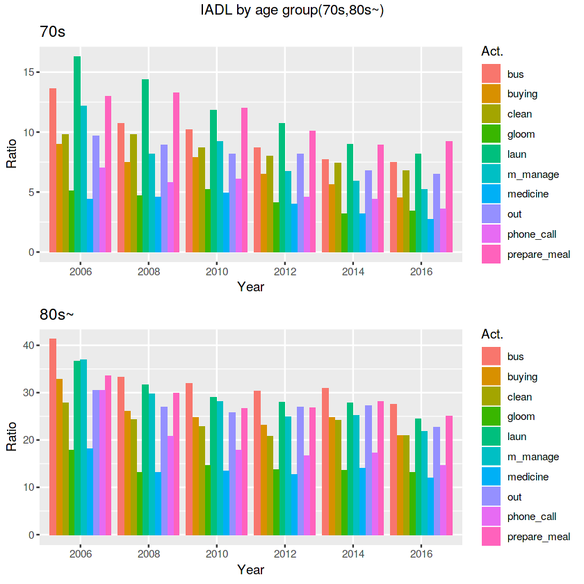

```r
ggplot(iadl_bind[iadl_bind$ageg=="70s",],aes(factor(year),pct,fill=factor(class)))+
    geom_col(position="dodge")+
    labs(y="Ratio",x="Year",title="70s") +
    theme_grey()+
    scale_fill_discrete(name = "Act.")->iadl1

ggplot(iadl_bind[iadl_bind$ageg=="80s~",],aes(factor(year),pct,fill=factor(class)))+
    geom_col(position="dodge")+
    labs(y="Ratio",x="Year",title="80s~") +
    theme_grey()+
    scale_fill_discrete(name = "Act.")->iadl2

grid.arrange(iadl1, iadl2, top="IADL by age group(70s,80s~)", nrow = 2)
```

### 6.3 음주 및 흡연과 만성질환

```r
klosa %>% select(year,gender,ageg,alcohol,smoke,hypertension,diabetes,cancer,lung_disease,liver_disease,heart_disease,cerebrovascular_disease) %>%
    mutate(hypertension=ifelse(hypertension==1,1,0)) %>%
    mutate(diabetes=ifelse(diabetes==1,1,0)) %>%
    mutate(cancer=ifelse(cancer==1,1,0)) %>%
    mutate(lung_disease =ifelse(lung_disease==1,1,0)) %>%
    mutate(liver_disease=ifelse(liver_disease==1,1,0)) %>%
    mutate(heart_disease=ifelse(heart_disease==1,1,0)) %>%
    mutate(cerebrovascular_disease=ifelse(cerebrovascular_disease==1,1,0)) %>%
    mutate(chronic_sum=hypertension+diabetes+cancer+lung_disease+liver_disease+heart_disease+cerebrovascular_disease)->cerebrovascular_data
```

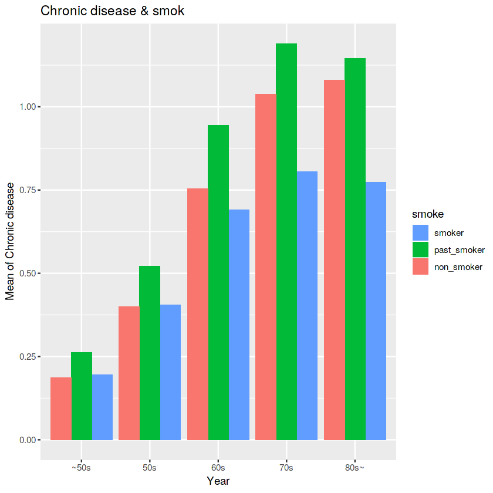

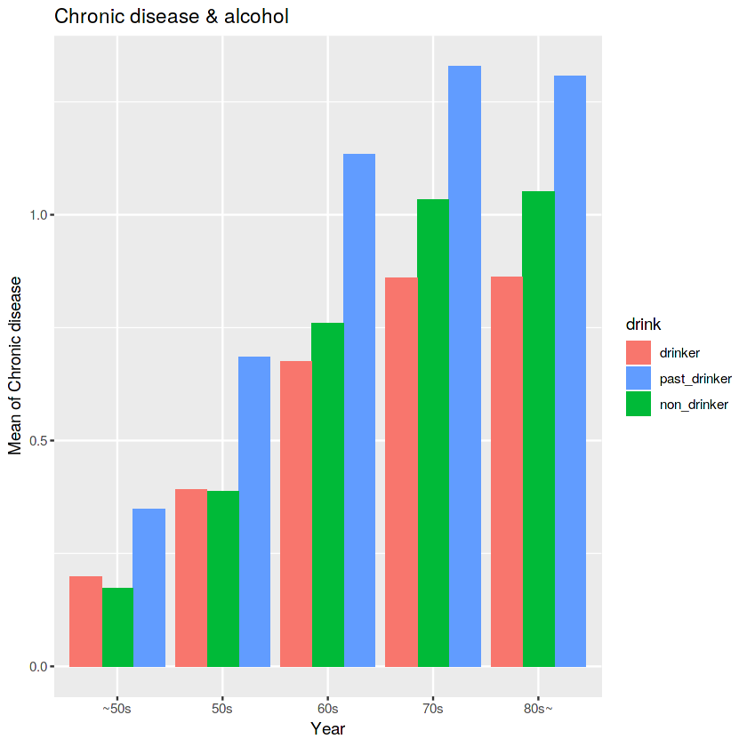

```r
#흡연자와 평균 만성질환갯수
cerebrovascular_data %>% filter(!is.na(smoke)) %>% filter(!is.na(chronic_sum)) %>%
  filter(smoke==2) %>% select(ageg, chronic_sum) %>%
  group_by(ageg) %>% summarize(smoker=mean(chronic_sum)) ->smo1


cerebrovascular_data %>% filter(!is.na(smoke)) %>% filter(!is.na(chronic_sum)) %>%
  filter(smoke==1) %>% select(ageg, chronic_sum) %>%
  group_by(ageg) %>% summarize(past_smoker=mean(chronic_sum))->smo2

cerebrovascular_data %>% filter(!is.na(smoke)) %>% filter(!is.na(chronic_sum)) %>%
  filter(smoke==0) %>% select(ageg, chronic_sum) %>%
  group_by(ageg) %>% summarize(non_smoker=mean(chronic_sum))->smo3

left_join(smo1,smo2, by='ageg')->smoke
left_join(smoke,smo3, by='ageg')->smoke
gather(smoke, key="smoke", value="mean",`smoker`,`past_smoker`,`non_smoker`) %>%
  ggplot(aes(factor(ageg),mean,fill=smoke))+geom_col(position="dodge")+
  scale_fill_discrete(breaks=c("smoker","past_smoker","non_smoker"))+
  labs(y="Mean of Chronic disease",x="Year",title="Chronic disease & smok")

#음주자와 평균 만성질환갯수
cerebrovascular_data %>% filter(!is.na(alcohol)) %>% filter(!is.na(chronic_sum)) %>%
    filter(alcohol==1) %>% select(ageg, chronic_sum) %>%
    group_by(ageg) %>% summarize(drinker=mean(chronic_sum)) ->ac1


  cerebrovascular_data %>% filter(!is.na(alcohol)) %>% filter(!is.na(chronic_sum)) %>%
    filter(alcohol==2) %>% select(ageg, chronic_sum) %>%
    group_by(ageg) %>% summarize(past_drinker=mean(chronic_sum))->ac2

  cerebrovascular_data %>% filter(!is.na(alcohol)) %>% filter(!is.na(chronic_sum)) %>%
    filter(alcohol==3) %>% select(ageg, chronic_sum) %>%
    group_by(ageg) %>% summarize(non_drinker=mean(chronic_sum))->ac3

  left_join(ac1,ac2, by='ageg')->drink
  left_join(drink,ac3, by='ageg')->drink

  gather(drink, key="drink", value="mean",`drinker`,`past_drinker`,`non_drinker`) %>%
  ggplot(aes(factor(ageg),mean,fill=drink))+geom_col(position="dodge")+
    scale_fill_discrete(breaks=c("drinker","past_drinker","non_drinker"))+
    labs(y="Mean of Chronic disease",x="Year",title="Chronic disease & alcohol")
```

### 6.4 연령별 만성질환 상위 5개

### 만성질환

- hypertension:고혈압 / diabetes:당뇨병/고혈당 / cancer:암 및 악성종양 / lung_disease:폐질환
- liver_disease:간질환 / heart_disease:심장질환 / cerebrovascular_disease:뇌혈관질환
- mental_illness: 정신과적 질환 / arthritis: 관절염 또는 류마티스 / prostate_disease:전립선 질환

```r
klosa  %>% filter(!is.na(hypertension))  %>% select(ageg,hypertension)  %>%
     mutate(yes=ifelse(hypertension==1,1,NA)) %>% mutate(no=ifelse(hypertension==5,1,NA)) %>%
    mutate(class="hypertension") %>% select(ageg,yes,no,class)-> t1

klosa  %>% filter(!is.na(diabetes))  %>% select(ageg,diabetes) %>%
    mutate(yes=ifelse(diabetes==1,1,NA)) %>% mutate(no=ifelse(diabetes==5,1,NA)) %>%
    mutate(class="diabetes")%>% select(ageg,yes,no,class)-> t2

klosa  %>% filter(!is.na(cancer))  %>% select(ageg,cancer) %>%
    mutate(yes=ifelse(cancer==1,1,NA)) %>% mutate(no=ifelse(cancer==5,1,NA)) %>%
    mutate(class="cancer")%>% select(ageg,yes,no,class)-> t3

klosa  %>% filter(!is.na(lung_disease))  %>% select(ageg,lung_disease) %>%
    mutate(yes=ifelse(lung_disease==1,1,NA)) %>% mutate(no=ifelse(lung_disease==5,1,NA)) %>%
    mutate(class="lung_disease")%>% select(ageg,yes,no,class)-> t4

klosa  %>% filter(!is.na(liver_disease))  %>% select(ageg,liver_disease) %>%
    mutate(yes=ifelse(liver_disease==1,1,NA)) %>% mutate(no=ifelse(liver_disease==5,1,NA)) %>%
    mutate(class="liver_disease")%>% select(ageg,yes,no,class)-> t5

klosa  %>% filter(!is.na(heart_disease))  %>% select(ageg,heart_disease) %>%
    mutate(yes=ifelse(heart_disease==1,1,NA)) %>% mutate(no=ifelse(heart_disease==5,1,NA)) %>%
    mutate(class="heart_disease")%>% select(ageg,yes,no,class)-> t6

klosa  %>% filter(!is.na(cerebrovascular_disease))  %>% select(ageg,cerebrovascular_disease) %>%
    mutate(yes=ifelse(cerebrovascular_disease==1,1,NA)) %>% mutate(no=ifelse(cerebrovascular_disease==5,1,NA)) %>%
    mutate(class="cerebrovascular_disease")%>% select(ageg,yes,no,class)-> t7

klosa  %>% filter(!is.na(mental_illness))  %>% select(ageg,mental_illness) %>%
    mutate(yes=ifelse(mental_illness==1,1,NA)) %>% mutate(no=ifelse(mental_illness==5,1,NA)) %>%
    mutate(class="mental_illness")%>% select(ageg,yes,no,class)-> t8

klosa  %>% filter(!is.na(arthritis))  %>% select(ageg,arthritis) %>%
    mutate(yes=ifelse(arthritis==1,1,NA)) %>% mutate(no=ifelse(arthritis==5,1,NA)) %>%
    mutate(class="arthritis")%>% select(ageg,yes,no,class)-> t9

klosa  %>% filter(!is.na(prostate_disease))  %>% select(ageg,prostate_disease) %>%
    mutate(yes=ifelse(prostate_disease==1,1,NA)) %>% mutate(no=ifelse(prostate_disease==5,1,NA)) %>%
    mutate(class="prostate_disease")%>% select(ageg,yes,no,class)-> t10

rbind(t1,t2,t3,t4,t5,t6,t7,t8,t9,t10) -> a_rbind

sqldf("select ageg,class,sum(yes)/(sum(yes)+sum(no))*100.1 as ratio from a_rbind where ageg='~50s' group by ageg,class order by ageg,ratio desc limit 5") -> a1
sqldf("select ageg,class,sum(yes)/(sum(yes)+sum(no))*100.1 as ratio from a_rbind where ageg='50s' group by ageg,class order by ageg,ratio desc limit 5") -> a2
sqldf("select ageg,class,sum(yes)/(sum(yes)+sum(no))*100.1 as ratio from a_rbind where ageg='60s' group by ageg,class order by ageg,ratio desc limit 5") -> a3
sqldf("select ageg,class,sum(yes)/(sum(yes)+sum(no))*100.1 as ratio from a_rbind where ageg='70s' group by ageg,class order by ageg,ratio desc limit 5") -> a4
sqldf("select ageg,class,sum(yes)/(sum(yes)+sum(no))*100.1 as ratio from a_rbind where ageg='80s' group by ageg,class order by ageg,ratio desc limit 5") -> a5
sqldf("select ageg,class,sum(yes)/(sum(yes)+sum(no))*100.1 as ratio from a_rbind where ageg='80s~' group by ageg,class order by ageg,ratio desc limit 5") -> a6
rbind(a1,a2,a3,a4,a5,a6) -> b_rbind
```

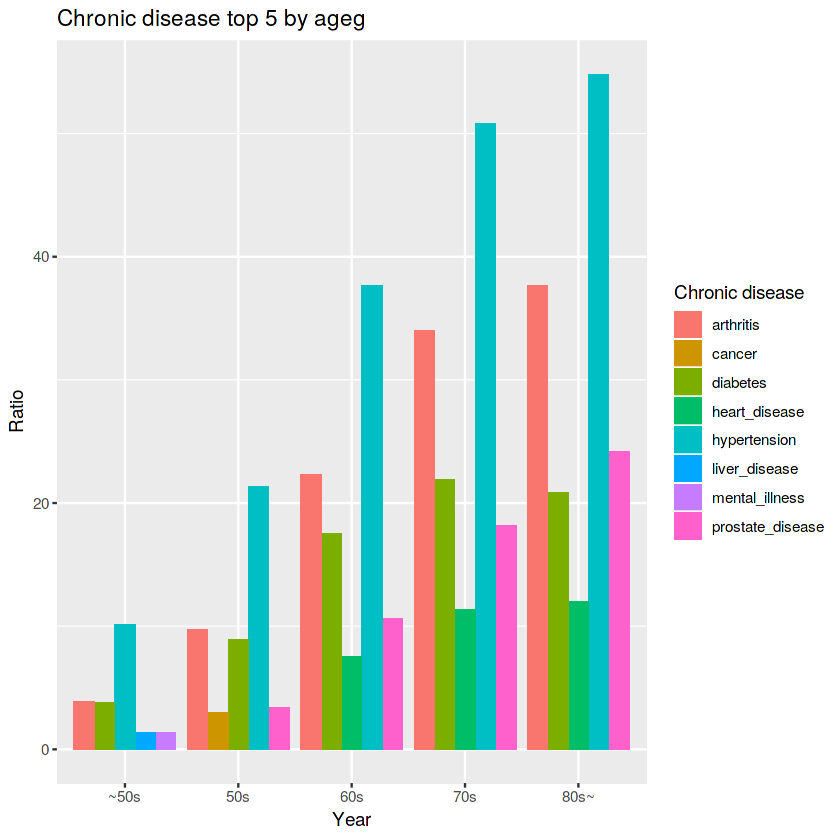

```r
b_rbind  %>% ggplot(aes(ageg,ratio,fill=class)) +
    geom_col(position="dodge")+
    labs(y="Ratio",x="Year",title="Chronic disease top 5 by ageg") +
    theme_grey()+
    scale_fill_discrete(name = "Chronic disease")
```

### 6.5 연령대별 인지기능

### 구분

- ~17 : 중증치매
- 18~23 : 의심,
- 24~ : 정상

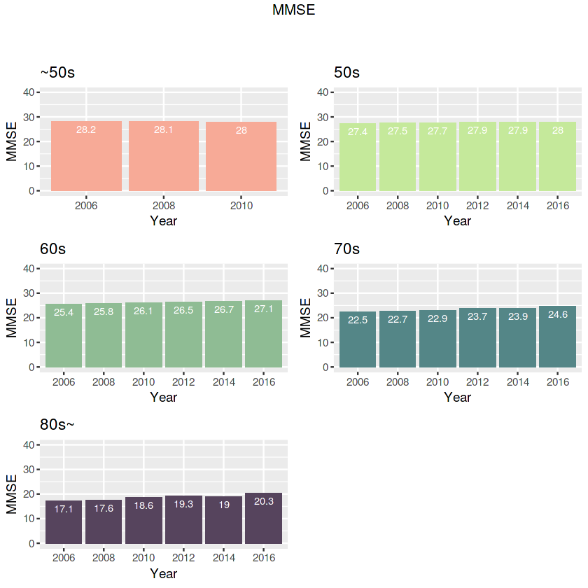

```r
klosa  %>% filter(!is.na(mmse))  %>% filter(ageg=='~50s') %>% select(ageg,mmse,year)  %>% group_by(year,ageg)  %>% summarize(mean=round(mean(mmse),1)) ->k1
klosa  %>% filter(!is.na(mmse))  %>% filter(ageg=='50s') %>% select(ageg,mmse,year)  %>% group_by(year,ageg)  %>% summarize(mean=round(mean(mmse),1)) ->k2
klosa  %>% filter(!is.na(mmse))  %>% filter(ageg=='60s') %>% select(ageg,mmse,year)  %>% group_by(year,ageg)  %>% summarize(mean=round(mean(mmse),1)) ->k3
klosa  %>% filter(!is.na(mmse))  %>% filter(ageg=='70s') %>% select(ageg,mmse,year)  %>% group_by(year,ageg)  %>% summarize(mean=round(mean(mmse),1)) ->k4
klosa  %>% filter(!is.na(mmse))  %>% filter(ageg=='80s~') %>% select(ageg,mmse,year)  %>% group_by(year,ageg)  %>% summarize(mean=round(mean(mmse),1))->k5


ggplot(k1,aes(factor(year),mean,fill=ageg))+geom_col(position="dodge",fill="#F7AA97")+
  ylim(0,40) + geom_text(aes(label=mean), vjust=1.5, colour="white", size=3)+labs(y="MMSE",x="Year",title="~50s")->k1
ggplot(k2,aes(factor(year),mean,fill=ageg))+geom_col(position="dodge",fill="#C5E99B")+
  ylim(0,40) + geom_text(aes(label=mean), vjust=1.5, colour="white", size=3)+labs(y="MMSE",x="Year",title="50s")->k2
ggplot(k3,aes(factor(year),mean,fill=ageg))+geom_col(position="dodge",fill="#8FBC94")+
  ylim(0,40) + geom_text(aes(label=mean), vjust=1.5, colour="white", size=3)+labs(y="MMSE",x="Year",title="60s")->k3
ggplot(k4,aes(factor(year),mean,fill=ageg))+geom_col(position="dodge",fill="#548687")+
  ylim(0,40) + geom_text(aes(label=mean), vjust=1.5, colour="white", size=3)+labs(y="MMSE",x="Year",title="70s")->k4
ggplot(k5,aes(factor(year),mean,fill=ageg))+geom_col(position="dodge",fill="#56445D")+
  ylim(0,40) + geom_text(aes(label=mean), vjust=1.5, colour="white", size=3)+labs(y="MMSE",x="Year",title="80s~")->k5

grid.arrange(k1 ,k2 ,k3 ,k4 ,k5 , ncol=2, top="MMSE\n\n")
```

### 6.6 삶의 질

### 1) 연령대별 전반적인 삶의 질 (0 ~ 100)

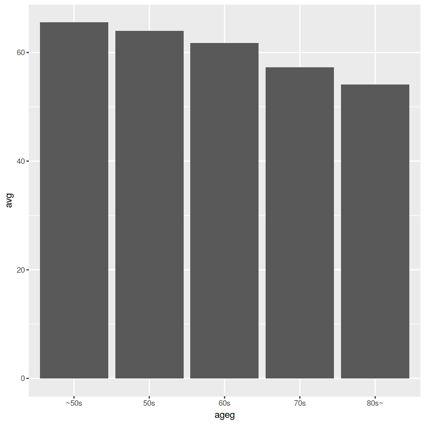

```r
klosa  %>% filter(!is.na(QOL))  %>% select(ageg,QOL)-> kk1
sqldf("select ageg,avg(QOL) as avg from kk1 group by ageg") ->kk2
kk2  %>% ggplot(aes(ageg,avg)) + geom_col()
```

### 2) 나이별 전반적인 삶의 질 (0 ~ 100)

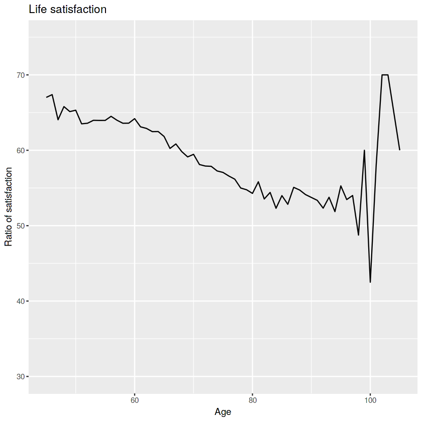

```r
klosa  %>% filter(!is.na(QOL))  %>% select(age,ageg,QOL)-> satisfaction
sqldf("select age,avg(QOL) as avg from satisfaction group by age") ->satisfaction
ggplot(satisfaction,aes(age,avg))+
    geom_line()+
    labs(y="Ratio of satisfaction",x="Age",title="Life satisfaction")+
    ylim(30,75)
```

### 6.7 연령별, 항목별 삶의 만족도

- perceived_health: 건강상태
- perceived_eco: 경제상태
- spouse_relationship: 배우자와의 관계
- children_relationship: 자녀와의 관계

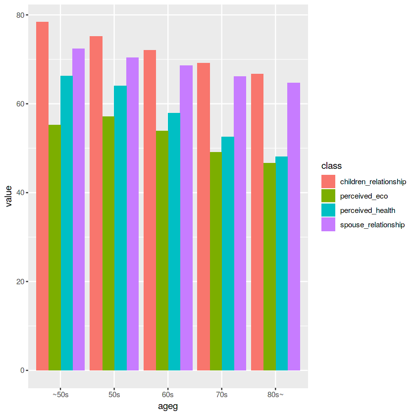

```r
klosa %>% filter(!is.na(perceived_health)) %>%
filter(!is.na(perceived_eco)) %>%
filter(!is.na(spouse_relationship)) %>%
filter(!is.na(children_relationship)) -> mm1

library(sqldf)

sqldf("select ageg,avg(perceived_health) as a_ph, avg(perceived_eco) as a_pe, avg(spouse_relationship) as a_sr, avg(children_relationship) as a_cr
            from mm1 group by ageg") -> pp1

pp1  %>% select(ageg,a_ph) %>% rename("value"=a_ph)  %>% mutate(class="perceived_health") -> s1
pp1  %>% select(ageg,a_pe) %>% rename("value"=a_pe)  %>% mutate(class="perceived_eco") -> s2
pp1  %>% select(ageg,a_sr) %>% rename("value"=a_sr)  %>% mutate(class="spouse_relationship") -> s3
pp1  %>% select(ageg,a_cr) %>% rename("value"=a_cr)  %>% mutate(class="children_relationship") -> s4

rbind(s1,s2,s3,s4) -> ss1

ss1   %>%  ggplot(aes(ageg,value,fill=class)) + geom_col(position="dodge")
```